# SIAMESE NETWORK WITH TRIPLET LOSS

## Table of Contents

1. Introduction
2. Setup
3. Data Loading and Pre-processing
4. Build and compile the model
5. Training the model
6. Making predictions
7. Evaluation
8. References

## **1. Introduction**

In this notebook, we implement and train a Siamese neural network using the triplet loss function, a powerful combination commonly used in tasks where measuring the similarity between inputs is more important than classifying them into fixed categories.

🎯 Objective

Our goal is to train a model that learns to project inputs (e.g., images, texts, embeddings) into a feature space where similar samples are closer together and dissimilar samples are farther apart. This is particularly useful for:

- Face recognition and verification
- Signature or fingerprint matching
- Recommender systems
- Metric learning applications

🧬 Why Triplet Loss?

Unlike contrastive loss (which uses pairs), triplet loss works by comparing anchor-positive-negative triplets:

- Anchor: A reference sample
- Positive: A sample of the same class as the anchor
- Negative: A sample of a different class

The loss encourages the distance between anchor and positive to be smaller than the distance between anchor and negative by at least a specified margin.

This encourages the network to learn discriminative embeddings that respect the desired similarity relationships.

## **2. Setup**

```python
import tensorflow as tf
from tensorflow.keras import layers, Model
import numpy as np
import matplotlib.pyplot as plt
from sklearn.manifold import TSNE
```

## **3. Data Loading and Pre-processing**

```python
# Load MNIST
(x_train, y_train), (x_test, y_test) = tf.keras.datasets.mnist.load_data()

x_train = x_train.astype("float32") / 255.
x_test = x_test.astype("float32") / 255.
x_train = np.expand_dims(x_train, -1)  # (60000, 28, 28, 1)
x_test = np.expand_dims(x_test, -1)    # (10000, 28, 28, 1)
```

Now, let's create the triplets.

```python
# Improved triplet creation
def create_triplets(x, y, num_triplets=5000):
    triplets = []
    num_classes = 10
    class_indices = [np.where(y == i)[0] for i in range(num_classes)]

    for _ in range(num_triplets):
        anchor_class = np.random.randint(0, num_classes)
        while len(class_indices[anchor_class]) < 2:
            anchor_class = np.random.randint(0, num_classes)

        anchor_idx, pos_idx = np.random.choice(class_indices[anchor_class], 2, replace=False)

        neg_class = np.random.randint(0, num_classes)
        while neg_class == anchor_class or len(class_indices[neg_class]) == 0:
            neg_class = np.random.randint(0, num_classes)
        neg_idx = np.random.choice(class_indices[neg_class])

        triplets.append([x[anchor_idx], x[pos_idx], x[neg_idx]])

    return np.array(triplets)

# Create triplets
triplets_train = create_triplets(x_train, y_train, num_triplets=10000)
triplets_test = create_triplets(x_test, y_test, num_triplets=2000)
```

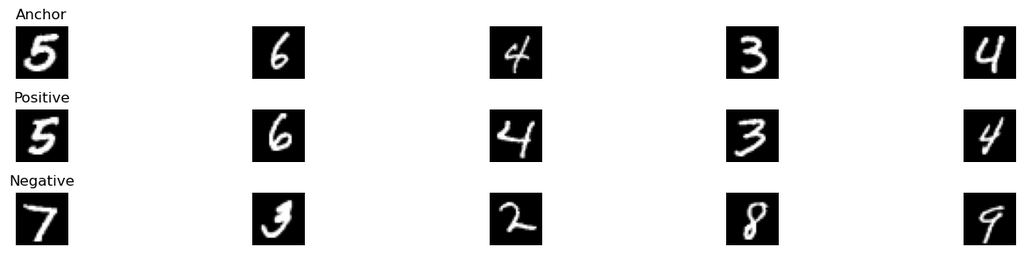

```python
# Visualize a few triplets
def plot_triplets(triplets, n=5):
    plt.figure(figsize=(n * 3, 3))
    for i in range(n):
        for j in range(3):
            plt.subplot(3, n, j * n + i + 1)
            plt.imshow(triplets[i, j].squeeze(), cmap='gray')
            plt.axis('off')
            if i == 0:
                plt.title(['Anchor', 'Positive', 'Negative'][j])
    plt.tight_layout()
    plt.show()

plot_triplets(triplets_train)
```

## **4. Build and compile the model**

First, lets create the **embedding network**.

The embedding network is the core of the Siamese architecture. It’s a neural network that maps raw input images into a dense vector space (i.e., embeddings) where semantic similarity corresponds to spatial closeness.

In this case, it will map each MNIST image (e.g., a 28x28 digit) to a 64-dimensional normalized vector.

The idea is that:

- Similar digits (e.g., two 3s) should have embeddings that are close together.
- Dissimilar digits (e.g., a 3 and an 8) should have embeddings far apart.

```python
# Base embedding network
def build_embedding_network(input_shape):
    inputs = layers.Input(shape=input_shape)
    x = layers.Conv2D(32, 3, activation='relu')(inputs)
    x = layers.MaxPooling2D()(x)
    x = layers.Conv2D(64, 3, activation='relu')(x)
    x = layers.MaxPooling2D()(x)
    x = layers.Flatten()(x)
    x = layers.Dense(64)(x)
    x = layers.Lambda(lambda x: tf.math.l2_normalize(x, axis=1))(x)
    return Model(inputs, x)
```

We will create the following **model**:

[figure not shown]

```python
# Siamese model that outputs distances
def build_siamese_model(embedding_network):
    anchor_input = layers.Input(shape=input_shape)
    positive_input = layers.Input(shape=input_shape)
    negative_input = layers.Input(shape=input_shape)

    a_embed = embedding_network(anchor_input)
    p_embed = embedding_network(positive_input)
    n_embed = embedding_network(negative_input)

    pos_dist = tf.reduce_sum(tf.square(a_embed - p_embed), axis=1, keepdims=True)
    neg_dist = tf.reduce_sum(tf.square(a_embed - n_embed), axis=1, keepdims=True)

    # Stack distances along last axis
    distances = layers.Concatenate(axis=-1)([pos_dist, neg_dist])
    return Model([anchor_input, positive_input, negative_input], distances)
```

**Triplet Loss**

The triplet loss ensures that an anchor image is closer to a positive image (same class) than to a negative image (different class), by at least a margin:

$$ \mathcal{L} = \max\left( \|f(a) - f(p)\|_2^2 - \|f(a) - f(n)\|_2^2 + \alpha, \, 0 \right) $$

Where:

- ( f(x) ): the embedding function (neural network)
- ( a ): anchor image
- ( p ): positive image (same class)
- ( n ): negative image (different class)
- ( \alpha ): margin (e.g., 0.5)

```python
# Triplet loss function
def triplet_loss(y_true, y_pred):
    pos_dist = y_pred[..., 0]  # Take first distance
    neg_dist = y_pred[..., 1]  # Take second distance
    margin = 0.5
    loss = tf.maximum(pos_dist - neg_dist + margin, 0.0)
    return tf.reduce_mean(loss)
```

Finally, let's build our model:

```python
# Get the shape of a single input image (e.g., (28, 28, 1) for MNIST)
input_shape = x_train.shape[1:]

# Build the embedding network that maps an image to a vector in embedding space
embedding_net = build_embedding_network(input_shape)

# Build the Siamese model that takes (anchor, positive, negative) images as input,
# uses the same embedding network on each, and outputs the positive and negative distances
model = build_siamese_model(embedding_net)

# Compile the model with Adam optimizer and custom triplet loss function
model.compile(
    optimizer=tf.keras.optimizers.Adam(0.001),
    loss=triplet_loss
)
```

## **5. Training the model**

```python
# Prepare data
anchor_train, positive_train, negative_train = triplets_train[:, 0], triplets_train[:, 1], triplets_train[:, 2]
anchor_test, positive_test, negative_test = triplets_test[:, 0], triplets_test[:, 1], triplets_test[:, 2]
```

```python
# Create dummy targets (though they won't be used)
dummy_y_train = np.zeros(len(anchor_train))
dummy_y_test = np.zeros(len(anchor_test))
```

Why do we need dummy outputs in model.fit:

The reason is that Keras always expects both:

- Inputs: your training data
- Targets (labels): what the model is trying to predict

However, in a Siamese network trained with triplet loss, you’re not predicting a label like a class index (e.g., "3" or "9"). Instead:

- The model computes the embedding distances between anchor-positive and anchor-negative.
- The loss function itself (triplet loss) compares these distances and computes how much to penalize the model — there's no need for ground-truth labels.

But Keras still requires a y_true argument for consistency, even if the loss doesn't use it.

```python
# Train
history = model.fit(
    [anchor_train, positive_train, negative_train],
    dummy_y_train,  # Dummy targets
    batch_size=128,
    epochs=5,
    validation_data=([anchor_test, positive_test, negative_test], dummy_y_test)
)
```

## **6. Making predictions**

```python
# Unpack the triplets
anchor_test, positive_test, negative_test = triplets_test[:, 0], triplets_test[:, 1], triplets_test[:, 2]

# Predict distances using the trained Siamese model
distances = model.predict([anchor_test, positive_test, negative_test])

# Separate the positive and negative distances
pos_dists = distances[:, 0]
neg_dists = distances[:, 1]
```

```python
distances.shape
```

```
(2000, 2)
```

```python
distances[0]
```

```
array([0.4046988, 2.29667  ], dtype=float32)
```

We can see that the output of our model is the positive and negative distances relative to the anchor.

## **7. Evaluation**

```python
# Compute how often positive distance is less than negative distance
correct = np.sum(pos_dists + 0.5 < neg_dists)  # using margin = 0.5
accuracy = correct / len(pos_dists)

print(f"Triplet accuracy (pos_dist + margin < neg_dist): {accuracy:.2%}")
```

```
Triplet accuracy (pos_dist + margin < neg_dist): 94.95%
```

Let's plot a few examples:

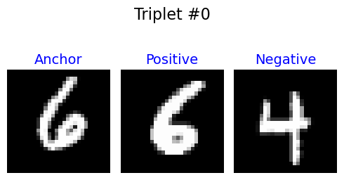

```
Positive dist: 0.4047, Negative dist: 2.2967
```

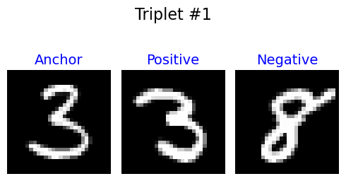

```
Positive dist: 0.2828, Negative dist: 2.5285
```

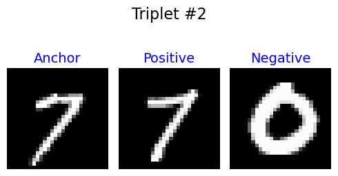

```
Positive dist: 0.1465, Negative dist: 1.8530
```

```python
def plot_triplet(anchor, positive, negative, i):
    plt.figure(figsize=(5, 3))

    titles = ['Anchor', 'Positive', 'Negative']
    images = [anchor, positive, negative]

    for idx, img in enumerate(images):
        plt.subplot(1, 3, idx + 1)
        plt.imshow(img.squeeze(), cmap='gray')
        plt.title(titles[idx], fontsize=14, color='blue')
        plt.axis('off')

    plt.suptitle(f"Triplet #{i}", fontsize=16)
    plt.tight_layout()
    plt.show()

# Plot first 3 triplets with clear labels
for i in range(3):
    plot_triplet(anchor_test[i], positive_test[i], negative_test[i], i)
    print(f"Positive dist: {pos_dists[i]:.4f}, Negative dist: {neg_dists[i]:.4f}")
```

Finally, let's plot our embeddings.

#### What to Expect?

- **Clusters Formed by Digit Classes**  
  Because the network is trained with triplet loss to pull embeddings of the same digit closer and push embeddings of different digits apart, we should see distinct clusters in the 2D plot, where each cluster corresponds roughly to one digit class (0 through 9).
- **Separation Between Clusters**  
  Ideally, the clusters for different digits will be well separated, reflecting that the network learned a meaningful embedding space where digits are distinguishable by their features.
- **Some Overlap or Noise**  
  Since MNIST digits can be similar (like '4' and '9' or '3' and '5'), you might see some overlap or fuzziness at the borders of clusters — that’s normal, especially with TSNE projections.
- **Compactness of Clusters**  
  The tighter the clusters, the better the embedding network learned to represent digit similarity. Loose or scattered clusters could mean the model needs more training or a different architecture.

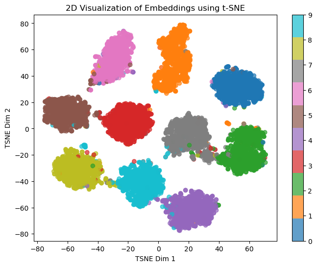

```python
# Step 1: Get embeddings for test images using the embedding network
# (Note: embedding_net is the base model without the triplet distance layers)
embeddings = embedding_net.predict(x_test)

# Step 2: Use TSNE to reduce to 2D
tsne = TSNE(n_components=2, random_state=42)
embeddings_2d = tsne.fit_transform(embeddings)

# Step 3: Plot embeddings with colors for each digit
plt.figure(figsize=(8, 6))
scatter = plt.scatter(embeddings_2d[:, 0], embeddings_2d[:, 1], c=y_test, cmap='tab10', alpha=0.7)
plt.colorbar(scatter, ticks=range(10))
plt.title("2D Visualization of Embeddings using t-SNE")
plt.xlabel("TSNE Dim 1")
plt.ylabel("TSNE Dim 2")
plt.show()
```

## **References**

[Deep Learning Specialization](https://www.coursera.org/learn/convolutional-neural-networks?specialization=deep-learning)